# Module 170

#### Hemi-module gene counts:

258 probesets in hemi-module A.  
66 probesets in hemi-module B.  
Note: While the mapping of probesets to genes is usually one-to-one, some genes are targeted by multiple probesets, some probesets target multiple genes, and some probesets do not target any genes (i.e., the region of the genome they match is no longer considered genic).

#### Contrast SVE:

Signed variance explained (SVE) provides an indication of how similar a set of fold changes are to a gene module’s weight vector. An SVE value of 0.3, for example, indicates that 30% of the variance explained by the entire module set is accounted for by the module in question. Shown here are the SVE values for this module across a compendium of fold changes (contrasts). Extreme SVE values (e.g., > 0.05) indicate that those contrasts specifically induce (orange dots) or specifically repress (blue dots) this module. Examining the experimental conditions being compared in such contrasts (see tables below the figure) may provide insight into the gene module’s function.

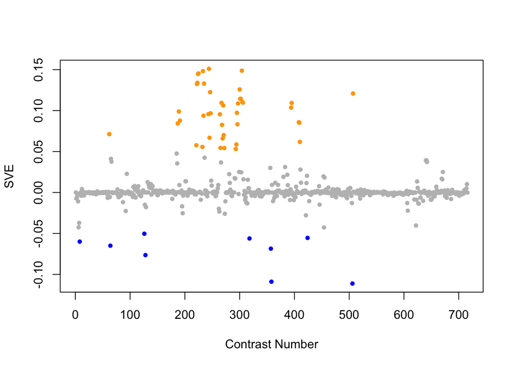

Positive SVE Contrasts:

|  | Contrast.Num | SVE | GEO.GSE | Cond.1 | Cond.2 | Mutation |
| --- | --- | --- | --- | --- | --- | --- |
| GSE42592C.s0t3.vs.s0t1 | 244 | 0.15 | GSE42592 | mercury_control_expose-8h_rep1 | mercury_control_expose-0h_rep1 |  |
| GSE41366C.s1t3.vs.s1t1 | 304 | 0.15 | GSE41366 | low_DDVP-continuous_expose-14h_harvest-rep1 | low_DDVP-continuous_expose-2h_harvest-rep1 |  |
| GSE42592B.s0t3.vs.s0t1 | 233 | 0.15 | GSE42592 | cadmium_control_expose-8h_rep1 | cadmium_control_expose-0h_rep1 |  |
| GSE42592A.s2t3.vs.s2t2 | 225 | 0.15 | GSE42592 | acrylamide_mid_expose-8h_rep1 | acrylamide_mid_expose-4h_rep1 |  |
| GSE42592A.s1t3.vs.s1t2 | 224 | 0.14 | GSE42592 | acrylamide_low_expose-8h_rep1 | acrylamide_low_expose-4h_rep1 |  |
| GSE42592A.s3t3.vs.s3t2 | 223 | 0.13 | GSE42592 | acrylamide_high_expose-8h_rep1 | acrylamide_high_expose-4h_rep1 |  |
| GSE42592B.s1t3.vs.s1t2 | 235 | 0.13 | GSE42592 | cadmium_low_expose-8h_rep1 | cadmium_low_expose-4h_rep1 |  |
| GSE42592A.s0t3.vs.s0t1 | 222 | 0.13 | GSE42592 | acrylamide_control_expose-8h_rep1 | acrylamide_control_expose-0h_rep1 |  |
| GSE41366C.s2t3.vs.s2t1 | 300 | 0.13 | GSE41366 | high_DDVP-continuous_expose-14h_harvest-rep1 | high_DDVP-continuous_expose-2h_harvest-rep1 |  |
| GSE42592C.s1t3.vs.s1t2 | 246 | 0.12 | GSE42592 | mercury_low_expose-8h_rep1 | mercury_low_expose-4h_rep1 |  |
| GSE2210.s2t1.vs.s0t1 | 507 | 0.12 | GSE2210 | unc-43(n1186) Sample 1 | Wild type Sample 1 | unc-43 |
| GSE41366C.s2t5.vs.s2t1 | 302 | 0.11 | GSE41366 | high_DDVP-continuous_expose-26h_harvest-rep1 | high_DDVP-continuous_expose-2h_harvest-rep1 |  |
| GSE41366C.s2t4.vs.s2t1 | 301 | 0.11 | GSE41366 | high_DDVP-continuous_expose-20h_harvest-rep1 | high_DDVP-continuous_expose-2h_harvest-rep1 |  |
| GSE41366C.s1t4.vs.s1t1 | 305 | 0.11 | GSE41366 | low_DDVP-continuous_expose-20h_harvest-rep1 | low_DDVP-continuous_expose-2h_harvest-rep1 |  |
| GSE41366C.s1t5.vs.s1t1 | 306 | 0.11 | GSE41366 | low_DDVP-continuous_expose-26h_harvest-rep1 | low_DDVP-continuous_expose-2h_harvest-rep1 |  |
| GSE41366A.s2t2.vs.s2t1 | 267 | 0.11 | GSE41366 | high_DDVP-2h_expose-14h_harvest-rep1 | high_DDVP-2h_expose-8h_harvest-rep1 |  |
| GSE32339.s0t2.vs.s0t1 | 395 | 0.11 | GSE32339 | Adult Wild-type, biological rep1 | Larval Wild-type, biological rep1 |  |
| GSE41366C.s0t6.vs.s0t1 | 297 | 0.11 | GSE41366 | control-continuous_expose-26h_harvest-rep1 | control-continuous_expose-0h_harvest-rep2 |  |
| GSE41366A.s1t2.vs.s1t1 | 270 | 0.11 | GSE41366 | low_DDVP-2h_expose-14h_harvest-rep1 | low_DDVP-2h_expose-8h_harvest-rep1 |  |
| GSE32339.s1t2.vs.s1t1 | 394 | 0.10 | GSE32339 | Adult Mutant, biological rep1 | Larval Mutant, biological rep1 |  |
| GSE46291.s1t3.vs.s1t1 | 189 | 0.10 | GSE46291 | Adult_rep1 | L3_rep1 |  |
| GSE41366C.s0t4.vs.s0t1 | 295 | 0.10 | GSE41366 | control-continuous_expose-14h_harvest-rep1 | control-continuous_expose-0h_harvest-rep2 |  |
| GSE42592C.s2t3.vs.s2t2 | 247 | 0.10 | GSE42592 | mercury_mid_expose-8h_rep1 | mercury_mid_expose-4h_rep1 |  |
| GSE42592C.s0t2.vs.s0t1 | 243 | 0.10 | GSE42592 | mercury_control_expose-4h_rep1 | mercury_control_expose-0h_rep1 |  |
| GSE41366A.s0t2.vs.s0t1 | 264 | 0.10 | GSE41366 | control-2h_expose-14h_harvest-rep1 | control-2h_expose-8h_harvest-rep1 |  |
| GSE42592B.s3t3.vs.s3t2 | 234 | 0.09 | GSE42592 | cadmium_high_expose-8h_rep1 | cadmium_high_expose-4h_rep1 |  |
| GSE46291.s2t2.vs.s2t1 | 191 | 0.09 | GSE46291 | L4-lethargus_rep1 | L3-lethargus_rep1 |  |
| GSE30505.s1t1.vs.s2t1 | 408 | 0.09 | GSE30505 | L3 N2 (WT) E.V. #1 | L3 N2 (WT) ash-2 #1 | ash-2 |
| GSE30505.s4t2.vs.s4t1 | 409 | 0.09 | GSE30505 | Day 8 glp-1 ash-2 #1 | L3 glp-1 ash-2 #1 |  |
| GSE46291.s2t2.vs.s1t2 | 187 | 0.08 | GSE46291 | L4-lethargus_rep1 | L4_rep1 |  |
| GSE41366C.s0t5.vs.s0t1 | 296 | 0.08 | GSE41366 | control-continuous_expose-20h_harvest-rep1 | control-continuous_expose-0h_harvest-rep2 |  |
| GSE41366A.s2t3.vs.s2t1 | 268 | 0.08 | GSE41366 | high_DDVP-2h_expose-20h_harvest-rep1 | high_DDVP-2h_expose-8h_harvest-rep1 |  |
| GSE8696.s1t1.vs.s2t1 | 62 | 0.07 | GSE8696 | 4 uM hemin (4A) | 20 uM hemin (20A) |  |
| GSE41366A.s1t3.vs.s1t1 | 271 | 0.07 | GSE41366 | low_DDVP-2h_expose-20h_harvest-rep1 | low_DDVP-2h_expose-8h_harvest-rep1 |  |
| GSE42592C.s3t3.vs.s3t2 | 245 | 0.07 | GSE42592 | mercury_high_expose-8h_rep1 | mercury_high_expose-4h_rep1 |  |
| GSE41366A.s2t4.vs.s2t1 | 269 | 0.07 | GSE41366 | high_DDVP-2h_expose-26h_harvest-rep1 | high_DDVP-2h_expose-8h_harvest-rep1 |  |
| GSE30505.s3t2.vs.s3t1 | 410 | 0.06 | GSE30505 | Day 8 glp-1 E.V. #1 | L3 glp-1 E.V. #1 |  |
| GSE41366C.s1t3.vs.s0t3 | 294 | 0.06 | GSE41366 | low_DDVP-continuous_expose-14h_harvest-rep1 | control-continuous_expose-8h_harvest-rep1 |  |
| GSE42592A.s0t2.vs.s0t1 | 221 | 0.06 | GSE42592 | acrylamide_control_expose-4h_rep1 | acrylamide_control_expose-0h_rep1 |  |
| GSE42592B.s0t2.vs.s0t1 | 232 | 0.06 | GSE42592 | cadmium_control_expose-4h_rep1 | cadmium_control_expose-0h_rep1 |  |
| GSE41366A.s0t3.vs.s0t1 | 265 | 0.05 | GSE41366 | control-2h_expose-20h_harvest-rep1 | control-2h_expose-8h_harvest-rep1 |  |
| GSE41366A.s1t4.vs.s1t1 | 272 | 0.05 | GSE41366 | low_DDVP-2h_expose-26h_harvest-rep1 | low_DDVP-2h_expose-8h_harvest-rep1 |  |
| GSE41366C.s2t3.vs.s0t3 | 293 | 0.05 | GSE41366 | high_DDVP-continuous_expose-14h_harvest-rep1 | control-continuous_expose-8h_harvest-rep1 |  |

Negative SVE Contrasts:

|  | Contrast.Num | SVE | GEO.GSE | Cond.1 | Cond.2 | Mutation |
| --- | --- | --- | --- | --- | --- | --- |
| GSE2210.s1t1.vs.s0t1 | 506 | -0.11 | GSE2210 | tom-1(nu468) Sample 1 | Wild type Sample 1 | tom-1 |
| GSE38196.s1t2.vs.s1t1 | 358 | -0.11 | GSE38196 | atfs-1(tm4525)-treated, biological rep1 | atfs-1(tm4525)-control, biological rep1 | spg-7(RNAi) |
| GSE54011.s3t1.vs.s0t1 | 128 | -0.08 | GSE54011 | Ce 0.2 mM Se | Ce 0 mM Se |  |
| GSE38196.s1t2.vs.s0t2 | 357 | -0.07 | GSE38196 | atfs-1(tm4525)-treated, biological rep1 | wild-type-treated, biological rep1 | afts-1 |
| GSE8696.s3t1.vs.s1t1 | 64 | -0.06 | GSE8696 | 500 uM hemin (500A) | 4 uM hemin (4A) |  |
| GSE9897B.s5t1.vs.s0t1 | 8 | -0.06 | GSE9897 | Complex I RNAi Mutant 5 | Wildtype (control for RNAi) | D2030.4 |
| GSE39012.s2t1.vs.s0t1 | 318 | -0.06 | GSE39012 | L3 stage worm AS_.003, biological replicate 1 | L3 stage worm AS_Control, biological replicate 1 |  |
| GSE27867.s1t1.vs.s0t1 | 424 | -0.06 | GSE27867 | tag-24, biological rep1 | wt, biological rep1 | tag-24 |
| GSE54011.s1t1.vs.s0t1 | 126 | -0.05 | GSE54011 | Ce 0.05 mM Se | Ce 0 mM Se |  |

$~$

#### Contrast SVE, Up-Regulated Genes Only:

Calculating SVE for up-regulated and down-regulated genes separately may be more informative in many cases than projecting the up- and down- gene sets together. This is due to the fact that the weight distribution of many modules is highly skewed, indicating that only one of the hemi-modules may be biologically meaningful (i.e., a set of genes are strongly correlated by only a few genes (or none) are strongly anti-correlated to that set.)

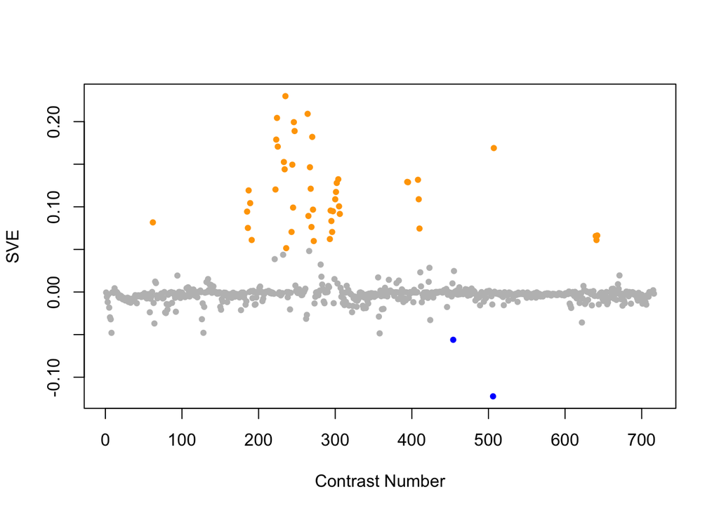

Positive SVE Contrasts:

|  | Contrast.Num | SVE | GEO.GSE | Cond.1 | Cond.2 | Mutation |
| --- | --- | --- | --- | --- | --- | --- |
| GSE42592B.s1t3.vs.s1t2 | 235 | 0.23 | GSE42592 | cadmium_low_expose-8h_rep1 | cadmium_low_expose-4h_rep1 |  |
| GSE41366A.s0t2.vs.s0t1 | 264 | 0.21 | GSE41366 | control-2h_expose-14h_harvest-rep1 | control-2h_expose-8h_harvest-rep1 |  |
| GSE42592A.s1t3.vs.s1t2 | 224 | 0.20 | GSE42592 | acrylamide_low_expose-8h_rep1 | acrylamide_low_expose-4h_rep1 |  |
| GSE42592C.s1t3.vs.s1t2 | 246 | 0.20 | GSE42592 | mercury_low_expose-8h_rep1 | mercury_low_expose-4h_rep1 |  |
| GSE42592C.s2t3.vs.s2t2 | 247 | 0.19 | GSE42592 | mercury_mid_expose-8h_rep1 | mercury_mid_expose-4h_rep1 |  |
| GSE41366A.s1t2.vs.s1t1 | 270 | 0.18 | GSE41366 | low_DDVP-2h_expose-14h_harvest-rep1 | low_DDVP-2h_expose-8h_harvest-rep1 |  |
| GSE42592A.s3t3.vs.s3t2 | 223 | 0.18 | GSE42592 | acrylamide_high_expose-8h_rep1 | acrylamide_high_expose-4h_rep1 |  |
| GSE42592A.s2t3.vs.s2t2 | 225 | 0.17 | GSE42592 | acrylamide_mid_expose-8h_rep1 | acrylamide_mid_expose-4h_rep1 |  |
| GSE2210.s2t1.vs.s0t1 | 507 | 0.17 | GSE2210 | unc-43(n1186) Sample 1 | Wild type Sample 1 | unc-43 |
| GSE42592B.s0t3.vs.s0t1 | 233 | 0.15 | GSE42592 | cadmium_control_expose-8h_rep1 | cadmium_control_expose-0h_rep1 |  |
| GSE42592C.s0t3.vs.s0t1 | 244 | 0.15 | GSE42592 | mercury_control_expose-8h_rep1 | mercury_control_expose-0h_rep1 |  |
| GSE41366A.s2t2.vs.s2t1 | 267 | 0.15 | GSE41366 | high_DDVP-2h_expose-14h_harvest-rep1 | high_DDVP-2h_expose-8h_harvest-rep1 |  |
| GSE42592B.s3t3.vs.s3t2 | 234 | 0.14 | GSE42592 | cadmium_high_expose-8h_rep1 | cadmium_high_expose-4h_rep1 |  |
| GSE41366C.s1t3.vs.s1t1 | 304 | 0.13 | GSE41366 | low_DDVP-continuous_expose-14h_harvest-rep1 | low_DDVP-continuous_expose-2h_harvest-rep1 |  |
| GSE30505.s1t1.vs.s2t1 | 408 | 0.13 | GSE30505 | L3 N2 (WT) E.V. #1 | L3 N2 (WT) ash-2 #1 | ash-2 |
| GSE32339.s1t2.vs.s1t1 | 394 | 0.13 | GSE32339 | Adult Mutant, biological rep1 | Larval Mutant, biological rep1 |  |
| GSE32339.s0t2.vs.s0t1 | 395 | 0.13 | GSE32339 | Adult Wild-type, biological rep1 | Larval Wild-type, biological rep1 |  |
| GSE41366C.s2t5.vs.s2t1 | 302 | 0.13 | GSE41366 | high_DDVP-continuous_expose-26h_harvest-rep1 | high_DDVP-continuous_expose-2h_harvest-rep1 |  |
| GSE41366A.s2t3.vs.s2t1 | 268 | 0.12 | GSE41366 | high_DDVP-2h_expose-20h_harvest-rep1 | high_DDVP-2h_expose-8h_harvest-rep1 |  |
| GSE42592A.s0t3.vs.s0t1 | 222 | 0.12 | GSE42592 | acrylamide_control_expose-8h_rep1 | acrylamide_control_expose-0h_rep1 |  |
| GSE46291.s2t2.vs.s1t2 | 187 | 0.12 | GSE46291 | L4-lethargus_rep1 | L4_rep1 |  |
| GSE41366C.s2t4.vs.s2t1 | 301 | 0.12 | GSE41366 | high_DDVP-continuous_expose-20h_harvest-rep1 | high_DDVP-continuous_expose-2h_harvest-rep1 |  |
| GSE30505.s4t2.vs.s4t1 | 409 | 0.11 | GSE30505 | Day 8 glp-1 ash-2 #1 | L3 glp-1 ash-2 #1 |  |
| GSE41366C.s2t3.vs.s2t1 | 300 | 0.11 | GSE41366 | high_DDVP-continuous_expose-14h_harvest-rep1 | high_DDVP-continuous_expose-2h_harvest-rep1 |  |
| GSE46291.s1t3.vs.s1t1 | 189 | 0.10 | GSE46291 | Adult_rep1 | L3_rep1 |  |
| GSE41366C.s1t4.vs.s1t1 | 305 | 0.10 | GSE41366 | low_DDVP-continuous_expose-20h_harvest-rep1 | low_DDVP-continuous_expose-2h_harvest-rep1 |  |
| GSE42592C.s3t3.vs.s3t2 | 245 | 0.10 | GSE42592 | mercury_high_expose-8h_rep1 | mercury_high_expose-4h_rep1 |  |
| GSE41366A.s1t3.vs.s1t1 | 271 | 0.10 | GSE41366 | low_DDVP-2h_expose-20h_harvest-rep1 | low_DDVP-2h_expose-8h_harvest-rep1 |  |
| GSE41366C.s1t3.vs.s0t3 | 294 | 0.10 | GSE41366 | low_DDVP-continuous_expose-14h_harvest-rep1 | control-continuous_expose-8h_harvest-rep1 |  |
| GSE41366C.s0t6.vs.s0t1 | 297 | 0.09 | GSE41366 | control-continuous_expose-26h_harvest-rep1 | control-continuous_expose-0h_harvest-rep2 |  |
| GSE4766.s1t3.vs.s1t1 | 185 | 0.09 | GSE4766 | Pooled glp-1 C elegans old adults_rep1 | Pooled glp-1 C elegans embryos_bleach NaOH prep_rep1 |  |
| GSE41366C.s1t5.vs.s1t1 | 306 | 0.09 | GSE41366 | low_DDVP-continuous_expose-26h_harvest-rep1 | low_DDVP-continuous_expose-2h_harvest-rep1 |  |
| GSE41366A.s0t3.vs.s0t1 | 265 | 0.09 | GSE41366 | control-2h_expose-20h_harvest-rep1 | control-2h_expose-8h_harvest-rep1 |  |
| GSE41366C.s0t4.vs.s0t1 | 295 | 0.08 | GSE41366 | control-continuous_expose-14h_harvest-rep1 | control-continuous_expose-0h_harvest-rep2 |  |
| GSE8696.s1t1.vs.s2t1 | 62 | 0.08 | GSE8696 | 4 uM hemin (4A) | 20 uM hemin (20A) |  |
| GSE41366A.s2t4.vs.s2t1 | 269 | 0.08 | GSE41366 | high_DDVP-2h_expose-26h_harvest-rep1 | high_DDVP-2h_expose-8h_harvest-rep1 |  |
| GSE4766.s1t2.vs.s1t1 | 186 | 0.08 | GSE4766 | Pooled glp-1 C elegans young adults_rep1 | Pooled glp-1 C elegans embryos_bleach NaOH prep_rep1 |  |
| GSE30505.s3t2.vs.s3t1 | 410 | 0.07 | GSE30505 | Day 8 glp-1 E.V. #1 | L3 glp-1 E.V. #1 |  |
| GSE42592C.s0t2.vs.s0t1 | 243 | 0.07 | GSE42592 | mercury_control_expose-4h_rep1 | mercury_control_expose-0h_rep1 |  |
| GSE41366C.s0t5.vs.s0t1 | 296 | 0.07 | GSE41366 | control-continuous_expose-20h_harvest-rep1 | control-continuous_expose-0h_harvest-rep2 |  |
| GSE18132.s0t2.vs.s0t1 | 642 | 0.07 | GSE18132 | WT Fed L4, biological rep1 | WT Starved L1, biological rep1 |  |
| GSE18132.s2t2.vs.s2t1 | 640 | 0.07 | GSE18132 | Oga Fed L4, biological replicate 1 | Oga starved L1, biological replicate 1 |  |
| GSE41366C.s2t3.vs.s0t3 | 293 | 0.06 | GSE41366 | high_DDVP-continuous_expose-14h_harvest-rep1 | control-continuous_expose-8h_harvest-rep1 |  |
| GSE46291.s2t2.vs.s2t1 | 191 | 0.06 | GSE46291 | L4-lethargus_rep1 | L3-lethargus_rep1 |  |
| GSE18132.s1t2.vs.s1t1 | 641 | 0.06 | GSE18132 | Ogt Fed L4, biological replicate 1 | Ogt starved L1, biological replicate 1 |  |
| GSE41366A.s1t4.vs.s1t1 | 272 | 0.06 | GSE41366 | low_DDVP-2h_expose-26h_harvest-rep1 | low_DDVP-2h_expose-8h_harvest-rep1 |  |
| GSE42592B.s2t3.vs.s2t2 | 236 | 0.05 | GSE42592 | cadmium_mid_expose-8h_rep1 | cadmium_mid_expose-4h_rep1 |  |

Negative SVE Contrasts:

[output not shown]

$~$

#### Contrast SVE, Down-Regulated Genes Only:

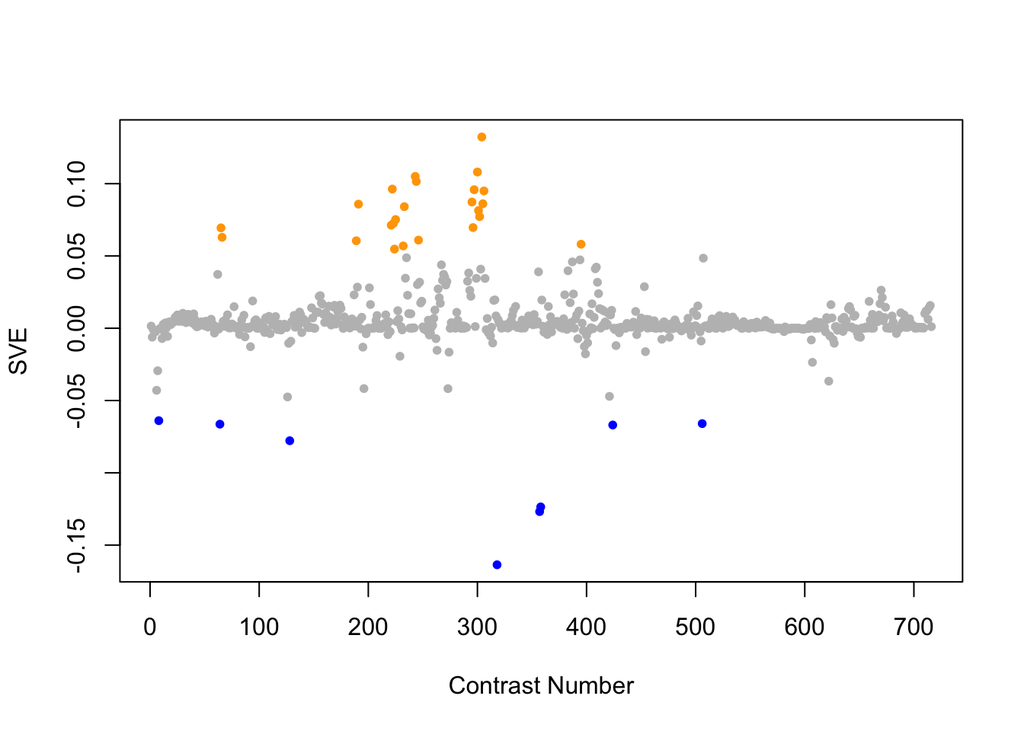

Positive SVE Contrasts:

|  | Contrast.Num | SVE | GEO.GSE | Cond.1 | Cond.2 | Mutation |
| --- | --- | --- | --- | --- | --- | --- |
| GSE41366C.s1t3.vs.s1t1 | 304 | 0.13 | GSE41366 | low_DDVP-continuous_expose-14h_harvest-rep1 | low_DDVP-continuous_expose-2h_harvest-rep1 |  |
| GSE41366C.s2t3.vs.s2t1 | 300 | 0.11 | GSE41366 | high_DDVP-continuous_expose-14h_harvest-rep1 | high_DDVP-continuous_expose-2h_harvest-rep1 |  |
| GSE42592C.s0t2.vs.s0t1 | 243 | 0.11 | GSE42592 | mercury_control_expose-4h_rep1 | mercury_control_expose-0h_rep1 |  |
| GSE42592C.s0t3.vs.s0t1 | 244 | 0.10 | GSE42592 | mercury_control_expose-8h_rep1 | mercury_control_expose-0h_rep1 |  |
| GSE42592A.s0t3.vs.s0t1 | 222 | 0.10 | GSE42592 | acrylamide_control_expose-8h_rep1 | acrylamide_control_expose-0h_rep1 |  |
| GSE41366C.s0t6.vs.s0t1 | 297 | 0.10 | GSE41366 | control-continuous_expose-26h_harvest-rep1 | control-continuous_expose-0h_harvest-rep2 |  |
| GSE41366C.s1t5.vs.s1t1 | 306 | 0.09 | GSE41366 | low_DDVP-continuous_expose-26h_harvest-rep1 | low_DDVP-continuous_expose-2h_harvest-rep1 |  |
| GSE41366C.s0t4.vs.s0t1 | 295 | 0.09 | GSE41366 | control-continuous_expose-14h_harvest-rep1 | control-continuous_expose-0h_harvest-rep2 |  |
| GSE41366C.s1t4.vs.s1t1 | 305 | 0.09 | GSE41366 | low_DDVP-continuous_expose-20h_harvest-rep1 | low_DDVP-continuous_expose-2h_harvest-rep1 |  |
| GSE46291.s2t2.vs.s2t1 | 191 | 0.09 | GSE46291 | L4-lethargus_rep1 | L3-lethargus_rep1 |  |
| GSE42592B.s0t3.vs.s0t1 | 233 | 0.08 | GSE42592 | cadmium_control_expose-8h_rep1 | cadmium_control_expose-0h_rep1 |  |
| GSE41366C.s2t4.vs.s2t1 | 301 | 0.08 | GSE41366 | high_DDVP-continuous_expose-20h_harvest-rep1 | high_DDVP-continuous_expose-2h_harvest-rep1 |  |
| GSE41366C.s2t5.vs.s2t1 | 302 | 0.08 | GSE41366 | high_DDVP-continuous_expose-26h_harvest-rep1 | high_DDVP-continuous_expose-2h_harvest-rep1 |  |
| GSE42592A.s2t3.vs.s2t2 | 225 | 0.08 | GSE42592 | acrylamide_mid_expose-8h_rep1 | acrylamide_mid_expose-4h_rep1 |  |
| GSE42592A.s3t3.vs.s3t2 | 223 | 0.07 | GSE42592 | acrylamide_high_expose-8h_rep1 | acrylamide_high_expose-4h_rep1 |  |
| GSE42592A.s0t2.vs.s0t1 | 221 | 0.07 | GSE42592 | acrylamide_control_expose-4h_rep1 | acrylamide_control_expose-0h_rep1 |  |
| GSE41366C.s0t5.vs.s0t1 | 296 | 0.07 | GSE41366 | control-continuous_expose-20h_harvest-rep1 | control-continuous_expose-0h_harvest-rep2 |  |
| GSE8659.s2t1.vs.s1t1 | 65 | 0.07 | GSE8659 | strain GR1373 replicate 1 | N2 replicate 1 | eri-1 |
| GSE8659.s3t1.vs.s1t1 | 66 | 0.06 | GSE8659 | strain NL 2099 replicate 2 | N2 replicate 1 | rrf-3 |
| GSE42592C.s1t3.vs.s1t2 | 246 | 0.06 | GSE42592 | mercury_low_expose-8h_rep1 | mercury_low_expose-4h_rep1 |  |
| GSE46291.s1t3.vs.s1t1 | 189 | 0.06 | GSE46291 | Adult_rep1 | L3_rep1 |  |
| GSE32339.s0t2.vs.s0t1 | 395 | 0.06 | GSE32339 | Adult Wild-type, biological rep1 | Larval Wild-type, biological rep1 |  |
| GSE42592B.s0t2.vs.s0t1 | 232 | 0.06 | GSE42592 | cadmium_control_expose-4h_rep1 | cadmium_control_expose-0h_rep1 |  |
| GSE42592A.s1t3.vs.s1t2 | 224 | 0.05 | GSE42592 | acrylamide_low_expose-8h_rep1 | acrylamide_low_expose-4h_rep1 |  |

Negative SVE Contrasts:

|  | Contrast.Num | SVE | GEO.GSE | Cond.1 | Cond.2 | Mutation |
| --- | --- | --- | --- | --- | --- | --- |
| GSE39012.s2t1.vs.s0t1 | 318 | -0.16 | GSE39012 | L3 stage worm AS_.003, biological replicate 1 | L3 stage worm AS_Control, biological replicate 1 |  |
| GSE38196.s1t2.vs.s0t2 | 357 | -0.13 | GSE38196 | atfs-1(tm4525)-treated, biological rep1 | wild-type-treated, biological rep1 | afts-1 |
| GSE38196.s1t2.vs.s1t1 | 358 | -0.12 | GSE38196 | atfs-1(tm4525)-treated, biological rep1 | atfs-1(tm4525)-control, biological rep1 | spg-7(RNAi) |
| GSE54011.s3t1.vs.s0t1 | 128 | -0.08 | GSE54011 | Ce 0.2 mM Se | Ce 0 mM Se |  |
| GSE27867.s1t1.vs.s0t1 | 424 | -0.07 | GSE27867 | tag-24, biological rep1 | wt, biological rep1 | tag-24 |
| GSE8696.s3t1.vs.s1t1 | 64 | -0.07 | GSE8696 | 500 uM hemin (500A) | 4 uM hemin (4A) |  |
| GSE2210.s1t1.vs.s0t1 | 506 | -0.07 | GSE2210 | tom-1(nu468) Sample 1 | Wild type Sample 1 | tom-1 |
| GSE9897B.s5t1.vs.s0t1 | 8 | -0.06 | GSE9897 | Complex I RNAi Mutant 5 | Wildtype (control for RNAi) | D2030.4 |

$~$

$~$

#### GO Term Enrichment:

This analysis tests each hemi-module for enrichment of specific GO terms. Only gene-level annotations (e.g., as would be found on the gene’s page in Wormbase) are tested - the hierarchical structure of the GO ontology is not taken into account.

*Note: At least the top two most enriched terms from each GO domain (BP/MF/CC) are shown, even when not statistically significant.*

##### Enriched GO terms: Hemi-module A

| ID | GO.Term | GO Domain | Raw p-value | Adj p-value |
| --- | --- | --- | --- | --- |
| [GO_0055085](http://amigo.geneontology.org/amigo/term/GO:0055085) | transmembrane transport | BP | 9.97e-06 | 3.63e-02 |
| [GO_0006520](http://amigo.geneontology.org/amigo/term/GO:0006520) | cellular amino acid metabolic process | BP | 1.54e-03 | 9.90e-01 |
| [GO_0042302](http://amigo.geneontology.org/amigo/term/GO:0042302) | structural constituent of cuticle | MF | 1.60e-10 | 3.26e-07 |
| [GO_0004046](http://amigo.geneontology.org/amigo/term/GO:0004046) | aminoacylase activity | MF | 8.64e-06 | 5.88e-03 |
| [GO_0045735](http://amigo.geneontology.org/amigo/term/GO:0045735) | nutrient reservoir activity | MF | 8.64e-06 | 5.88e-03 |
| [GO_0008237](http://amigo.geneontology.org/amigo/term/GO:0008237) | metallopeptidase activity | MF | 9.96e-05 | 5.09e-02 |
| [GO_0004222](http://amigo.geneontology.org/amigo/term/GO:0004222) | metalloendopeptidase activity | MF | 2.23e-04 | 8.18e-02 |
| [GO_0022857](http://amigo.geneontology.org/amigo/term/GO:0022857) | transmembrane transporter activity | MF | 2.40e-04 | 8.18e-02 |
| [GO_0005319](http://amigo.geneontology.org/amigo/term/GO:0005319) | lipid transporter activity | MF | 3.33e-04 | 9.72e-02 |
| [GO_0005634](http://amigo.geneontology.org/amigo/term/GO:0005634) | nucleus | CC | 5.55e-08 | 5.15e-05 |
| [GO_0005576](http://amigo.geneontology.org/amigo/term/GO:0005576) | extracellular region | CC | 1.47e-07 | 6.81e-05 |
| [GO_0042600](http://amigo.geneontology.org/amigo/term/GO:0042600) | chorion | CC | 1.69e-04 | 5.23e-02 |

##### Enriched GO terms: Hemi-module B

| ID | GO.Term | GO Domain | Raw p-value | Adj p-value |
| --- | --- | --- | --- | --- |
| [GO_1990179](http://amigo.geneontology.org/amigo/term/GO:1990179) | protein localization to actomyosin contractile ring | BP | 2.91e-03 | 1.00e+00 |
| [GO_0001764](http://amigo.geneontology.org/amigo/term/GO:0001764) | neuron migration | BP | 5.41e-03 | 1.00e+00 |
| [GO_0004867](http://amigo.geneontology.org/amigo/term/GO:0004867) | serine-type endopeptidase inhibitor activity | MF | 5.14e-03 | 1.00e+00 |
| [GO_0061598](http://amigo.geneontology.org/amigo/term/GO:0061598) | molybdopterin adenylyltransferase activity | MF | 5.81e-03 | 1.00e+00 |
| [GO_0030017](http://amigo.geneontology.org/amigo/term/GO:0030017) | sarcomere | CC | 2.18e-03 | 1.00e+00 |
| [GO_0099572](http://amigo.geneontology.org/amigo/term/GO:0099572) | postsynaptic specialization | CC | 5.81e-03 | 1.00e+00 |

$~$

$~$

#### Tissue Enrichment:

This analysis tests each hemi-module for enrichment of genes associated with anatomy terms. Negative enrichment scores indicate fewer hemi-module genes than expected by random chance were associated with the anatomy term in question.

##### Enriched tissues: Hemi-module A

No significant annotations.

##### Enriched tissues: Hemi-module B

No significant annotations.

$~$

$~$

#### HOMER promoter motif enrichment:

This analysis tests each hemi-module for enrichment of 108 known *C. elegans* transcription factor binding site motifs (see [108 CE motifs](https://katiepod.github.io//all.worm.motifs.html)) using the HOMER (Hypergeometric Optimization of Motif EnRichment) software (see [PMID:20513432](https://pubmed.ncbi.nlm.nih.gov/20513432)). HOMER was run using default parameters on sequences 1 kb upstream of the transcription start site.

##### Motif enrichment: Hemi-module A

Total target sequences = 214  
Total background sequences = 41551  
* - possible false positive

Rank

Motif

P-value

log P-pvalue

% of Targets

% of Background

STD(Bg STD)

Best Match/Details

Motif File

1

[figure not shown]

1e-13

-3.141e+01

10.75%

1.29%

307.8bp (325.3bp)

POL012.1_TATA-Box/Jaspar(0.809)  
[More Information](https://katiepod.github.io/HomerResults/m170_a_hemi_genes.txt.out.1kb/homerResults/motif1.info.html) | [Similar Motifs Found](https://katiepod.github.io/HomerResults/m170_a_hemi_genes.txt.out.1kb/homerResults/motif1.similar.html)

[motif file (matrix)](https://katiepod.github.io/HomerResults/m170_a_hemi_genes.txt.out.1kb/homerResults/motif1.motif)

2

[figure not shown]

1e-12

-2.874e+01

17.76%

4.39%

310.6bp (310.2bp)

LIN-39(Homeobox)/cElegans.L3-LIN39-ChIP-Seq(modEncode)/Homer(0.698)  
[More Information](https://katiepod.github.io/HomerResults/m170_a_hemi_genes.txt.out.1kb/homerResults/motif2.info.html) | [Similar Motifs Found](https://katiepod.github.io/HomerResults/m170_a_hemi_genes.txt.out.1kb/homerResults/motif2.similar.html)

[motif file (matrix)](https://katiepod.github.io/HomerResults/m170_a_hemi_genes.txt.out.1kb/homerResults/motif2.motif)

3 *

[figure not shown]

1e-11

-2.727e+01

5.14%

0.19%

235.5bp (320.8bp)

nhr-6/MA1451.1/Jaspar(0.632)  
[More Information](https://katiepod.github.io/HomerResults/m170_a_hemi_genes.txt.out.1kb/homerResults/motif3.info.html) | [Similar Motifs Found](https://katiepod.github.io/HomerResults/m170_a_hemi_genes.txt.out.1kb/homerResults/motif3.similar.html)

[motif file (matrix)](https://katiepod.github.io/HomerResults/m170_a_hemi_genes.txt.out.1kb/homerResults/motif3.motif)

4 *

[figure not shown]

1e-11

-2.566e+01

4.67%

0.16%

342.2bp (291.8bp)

atf-7/MA1438.1/Jaspar(0.610)  
[More Information](https://katiepod.github.io/HomerResults/m170_a_hemi_genes.txt.out.1kb/homerResults/motif4.info.html) | [Similar Motifs Found](https://katiepod.github.io/HomerResults/m170_a_hemi_genes.txt.out.1kb/homerResults/motif4.similar.html)

[motif file (matrix)](https://katiepod.github.io/HomerResults/m170_a_hemi_genes.txt.out.1kb/homerResults/motif4.motif)

5 *

[figure not shown]

1e-11

-2.543e+01

38.32%

18.43%

293.7bp (314.5bp)

blmp-1/MA0537.1/Jaspar(0.815)  
[More Information](https://katiepod.github.io/HomerResults/m170_a_hemi_genes.txt.out.1kb/homerResults/motif5.info.html) | [Similar Motifs Found](https://katiepod.github.io/HomerResults/m170_a_hemi_genes.txt.out.1kb/homerResults/motif5.similar.html)

[motif file (matrix)](https://katiepod.github.io/HomerResults/m170_a_hemi_genes.txt.out.1kb/homerResults/motif5.motif)

6 *

[figure not shown]

1e-10

-2.466e+01

7.48%

0.75%

193.3bp (309.1bp)

POL012.1_TATA-Box/Jaspar(0.549)  
[More Information](https://katiepod.github.io/HomerResults/m170_a_hemi_genes.txt.out.1kb/homerResults/motif6.info.html) | [Similar Motifs Found](https://katiepod.github.io/HomerResults/m170_a_hemi_genes.txt.out.1kb/homerResults/motif6.similar.html)

[motif file (matrix)](https://katiepod.github.io/HomerResults/m170_a_hemi_genes.txt.out.1kb/homerResults/motif6.motif)

7 *

[figure not shown]

1e-10

-2.397e+01

8.41%

1.07%

239.3bp (299.5bp)

nhr-6/MA1451.1/Jaspar(0.751)  
[More Information](https://katiepod.github.io/HomerResults/m170_a_hemi_genes.txt.out.1kb/homerResults/motif7.info.html) | [Similar Motifs Found](https://katiepod.github.io/HomerResults/m170_a_hemi_genes.txt.out.1kb/homerResults/motif7.similar.html)

[motif file (matrix)](https://katiepod.github.io/HomerResults/m170_a_hemi_genes.txt.out.1kb/homerResults/motif7.motif)

8 *

[figure not shown]

1e-10

-2.369e+01

6.54%

0.56%

299.9bp (327.5bp)

elt-6/MA1439.1/Jaspar(0.491)  
[More Information](https://katiepod.github.io/HomerResults/m170_a_hemi_genes.txt.out.1kb/homerResults/motif8.info.html) | [Similar Motifs Found](https://katiepod.github.io/HomerResults/m170_a_hemi_genes.txt.out.1kb/homerResults/motif8.similar.html)

[motif file (matrix)](https://katiepod.github.io/HomerResults/m170_a_hemi_genes.txt.out.1kb/homerResults/motif8.motif)

9 *

[figure not shown]

1e-10

-2.353e+01

6.54%

0.57%

282.3bp (292.9bp)

SD0002.1_at_AC_acceptor/Jaspar(0.690)  
[More Information](https://katiepod.github.io/HomerResults/m170_a_hemi_genes.txt.out.1kb/homerResults/motif9.info.html) | [Similar Motifs Found](https://katiepod.github.io/HomerResults/m170_a_hemi_genes.txt.out.1kb/homerResults/motif9.similar.html)

[motif file (matrix)](https://katiepod.github.io/HomerResults/m170_a_hemi_genes.txt.out.1kb/homerResults/motif9.motif)

10 *

[figure not shown]

1e-10

-2.322e+01

7.01%

0.71%

291.9bp (310.2bp)

fkh-9/MA1440.1/Jaspar(0.580)  
[More Information](https://katiepod.github.io/HomerResults/m170_a_hemi_genes.txt.out.1kb/homerResults/motif10.info.html) | [Similar Motifs Found](https://katiepod.github.io/HomerResults/m170_a_hemi_genes.txt.out.1kb/homerResults/motif10.similar.html)

[motif file (matrix)](https://katiepod.github.io/HomerResults/m170_a_hemi_genes.txt.out.1kb/homerResults/motif10.motif)

11 *

[figure not shown]

1e-9

-2.285e+01

8.41%

1.15%

235.7bp (308.4bp)

elt-2/MA1701.1/Jaspar(0.625)  
[More Information](https://katiepod.github.io/HomerResults/m170_a_hemi_genes.txt.out.1kb/homerResults/motif11.info.html) | [Similar Motifs Found](https://katiepod.github.io/HomerResults/m170_a_hemi_genes.txt.out.1kb/homerResults/motif11.similar.html)

[motif file (matrix)](https://katiepod.github.io/HomerResults/m170_a_hemi_genes.txt.out.1kb/homerResults/motif11.motif)

12 *

[figure not shown]

1e-9

-2.262e+01

10.75%

2.02%

233.0bp (321.6bp)

daf-16/MA1446.1/Jaspar(0.679)  
[More Information](https://katiepod.github.io/HomerResults/m170_a_hemi_genes.txt.out.1kb/homerResults/motif12.info.html) | [Similar Motifs Found](https://katiepod.github.io/HomerResults/m170_a_hemi_genes.txt.out.1kb/homerResults/motif12.similar.html)

[motif file (matrix)](https://katiepod.github.io/HomerResults/m170_a_hemi_genes.txt.out.1kb/homerResults/motif12.motif)

13 *

[figure not shown]

1e-9

-2.254e+01

11.68%

2.42%

273.0bp (308.1bp)

PL0017.1_hlh-2::hlh-10/Jaspar(0.587)  
[More Information](https://katiepod.github.io/HomerResults/m170_a_hemi_genes.txt.out.1kb/homerResults/motif13.info.html) | [Similar Motifs Found](https://katiepod.github.io/HomerResults/m170_a_hemi_genes.txt.out.1kb/homerResults/motif13.similar.html)

[motif file (matrix)](https://katiepod.github.io/HomerResults/m170_a_hemi_genes.txt.out.1kb/homerResults/motif13.motif)

14 *

[figure not shown]

1e-9

-2.237e+01

4.21%

0.16%

172.7bp (313.6bp)

fkh-9/MA1440.1/Jaspar(0.652)  
[More Information](https://katiepod.github.io/HomerResults/m170_a_hemi_genes.txt.out.1kb/homerResults/motif14.info.html) | [Similar Motifs Found](https://katiepod.github.io/HomerResults/m170_a_hemi_genes.txt.out.1kb/homerResults/motif14.similar.html)

[motif file (matrix)](https://katiepod.github.io/HomerResults/m170_a_hemi_genes.txt.out.1kb/homerResults/motif14.motif)

15 *

[figure not shown]

1e-9

-2.232e+01

5.14%

0.32%

322.0bp (301.1bp)

POL011.1_XCPE1/Jaspar(0.459)  
[More Information](https://katiepod.github.io/HomerResults/m170_a_hemi_genes.txt.out.1kb/homerResults/motif15.info.html) | [Similar Motifs Found](https://katiepod.github.io/HomerResults/m170_a_hemi_genes.txt.out.1kb/homerResults/motif15.similar.html)

[motif file (matrix)](https://katiepod.github.io/HomerResults/m170_a_hemi_genes.txt.out.1kb/homerResults/motif15.motif)

16 *

[figure not shown]

1e-9

-2.177e+01

5.61%

0.43%

209.5bp (292.8bp)

MF0011.1_HMG_class/Jaspar(0.539)  
[More Information](https://katiepod.github.io/HomerResults/m170_a_hemi_genes.txt.out.1kb/homerResults/motif16.info.html) | [Similar Motifs Found](https://katiepod.github.io/HomerResults/m170_a_hemi_genes.txt.out.1kb/homerResults/motif16.similar.html)

[motif file (matrix)](https://katiepod.github.io/HomerResults/m170_a_hemi_genes.txt.out.1kb/homerResults/motif16.motif)

17 *

[figure not shown]

1e-9

-2.131e+01

3.74%

0.12%

304.5bp (300.2bp)

MF0006.1_bZIP_cEBP-like_subclass/Jaspar(0.544)  
[More Information](https://katiepod.github.io/HomerResults/m170_a_hemi_genes.txt.out.1kb/homerResults/motif17.info.html) | [Similar Motifs Found](https://katiepod.github.io/HomerResults/m170_a_hemi_genes.txt.out.1kb/homerResults/motif17.similar.html)

[motif file (matrix)](https://katiepod.github.io/HomerResults/m170_a_hemi_genes.txt.out.1kb/homerResults/motif17.motif)

18 *

[figure not shown]

1e-9

-2.129e+01

11.21%

2.37%

282.8bp (313.6bp)

elt-2/MA1701.1/Jaspar(0.611)  
[More Information](https://katiepod.github.io/HomerResults/m170_a_hemi_genes.txt.out.1kb/homerResults/motif18.info.html) | [Similar Motifs Found](https://katiepod.github.io/HomerResults/m170_a_hemi_genes.txt.out.1kb/homerResults/motif18.similar.html)

[motif file (matrix)](https://katiepod.github.io/HomerResults/m170_a_hemi_genes.txt.out.1kb/homerResults/motif18.motif)

19 *

[figure not shown]

1e-9

-2.126e+01

12.62%

3.01%

291.3bp (305.5bp)

HLH-1(bHLH)/cElegans-Embryo-HLH1-ChIP-Seq(modEncode)/Homer(0.625)  
[More Information](https://katiepod.github.io/HomerResults/m170_a_hemi_genes.txt.out.1kb/homerResults/motif19.info.html) | [Similar Motifs Found](https://katiepod.github.io/HomerResults/m170_a_hemi_genes.txt.out.1kb/homerResults/motif19.similar.html)

[motif file (matrix)](https://katiepod.github.io/HomerResults/m170_a_hemi_genes.txt.out.1kb/homerResults/motif19.motif)

20 *

[figure not shown]

1e-9

-2.080e+01

3.27%

0.07%

246.9bp (313.2bp)

POL008.1_DCE_S_I/Jaspar(0.575)  
[More Information](https://katiepod.github.io/HomerResults/m170_a_hemi_genes.txt.out.1kb/homerResults/motif20.info.html) | [Similar Motifs Found](https://katiepod.github.io/HomerResults/m170_a_hemi_genes.txt.out.1kb/homerResults/motif20.similar.html)

[motif file (matrix)](https://katiepod.github.io/HomerResults/m170_a_hemi_genes.txt.out.1kb/homerResults/motif20.motif)

21 *

[figure not shown]

1e-9

-2.079e+01

11.68%

2.65%

341.6bp (309.6bp)

MF0004.1_Nuclear_Receptor_class/Jaspar(0.576)  
[More Information](https://katiepod.github.io/HomerResults/m170_a_hemi_genes.txt.out.1kb/homerResults/motif21.info.html) | [Similar Motifs Found](https://katiepod.github.io/HomerResults/m170_a_hemi_genes.txt.out.1kb/homerResults/motif21.similar.html)

[motif file (matrix)](https://katiepod.github.io/HomerResults/m170_a_hemi_genes.txt.out.1kb/homerResults/motif21.motif)

22 *

[figure not shown]

1e-8

-2.069e+01

6.54%

0.72%

256.6bp (306.1bp)

LIN-39(Homeobox)/cElegans.L3-LIN39-ChIP-Seq(modEncode)/Homer(0.615)  
[More Information](https://katiepod.github.io/HomerResults/m170_a_hemi_genes.txt.out.1kb/homerResults/motif22.info.html) | [Similar Motifs Found](https://katiepod.github.io/HomerResults/m170_a_hemi_genes.txt.out.1kb/homerResults/motif22.similar.html)

[motif file (matrix)](https://katiepod.github.io/HomerResults/m170_a_hemi_genes.txt.out.1kb/homerResults/motif22.motif)

23 *

[figure not shown]

1e-8

-2.043e+01

9.81%

1.88%

243.3bp (306.2bp)

lin-14/MA0261.1/Jaspar(0.691)  
[More Information](https://katiepod.github.io/HomerResults/m170_a_hemi_genes.txt.out.1kb/homerResults/motif23.info.html) | [Similar Motifs Found](https://katiepod.github.io/HomerResults/m170_a_hemi_genes.txt.out.1kb/homerResults/motif23.similar.html)

[motif file (matrix)](https://katiepod.github.io/HomerResults/m170_a_hemi_genes.txt.out.1kb/homerResults/motif23.motif)

24 *

[figure not shown]

1e-8

-1.983e+01

4.67%

0.30%

222.5bp (314.1bp)

MF0011.1_HMG_class/Jaspar(0.620)  
[More Information](https://katiepod.github.io/HomerResults/m170_a_hemi_genes.txt.out.1kb/homerResults/motif24.info.html) | [Similar Motifs Found](https://katiepod.github.io/HomerResults/m170_a_hemi_genes.txt.out.1kb/homerResults/motif24.similar.html)

[motif file (matrix)](https://katiepod.github.io/HomerResults/m170_a_hemi_genes.txt.out.1kb/homerResults/motif24.motif)

25 *

[figure not shown]

1e-8

-1.845e+01

10.75%

2.54%

269.9bp (302.9bp)

MF0003.1_REL_class/Jaspar(0.589)  
[More Information](https://katiepod.github.io/HomerResults/m170_a_hemi_genes.txt.out.1kb/homerResults/motif25.info.html) | [Similar Motifs Found](https://katiepod.github.io/HomerResults/m170_a_hemi_genes.txt.out.1kb/homerResults/motif25.similar.html)

[motif file (matrix)](https://katiepod.github.io/HomerResults/m170_a_hemi_genes.txt.out.1kb/homerResults/motif25.motif)

26 *

[figure not shown]

1e-7

-1.828e+01

8.41%

1.55%

269.6bp (307.8bp)

che-1/MA0260.1/Jaspar(0.558)  
[More Information](https://katiepod.github.io/HomerResults/m170_a_hemi_genes.txt.out.1kb/homerResults/motif26.info.html) | [Similar Motifs Found](https://katiepod.github.io/HomerResults/m170_a_hemi_genes.txt.out.1kb/homerResults/motif26.similar.html)

[motif file (matrix)](https://katiepod.github.io/HomerResults/m170_a_hemi_genes.txt.out.1kb/homerResults/motif26.motif)

27 *

[figure not shown]

1e-7

-1.804e+01

16.36%

5.59%

293.1bp (308.3bp)

POL012.1_TATA-Box/Jaspar(0.697)  
[More Information](https://katiepod.github.io/HomerResults/m170_a_hemi_genes.txt.out.1kb/homerResults/motif27.info.html) | [Similar Motifs Found](https://katiepod.github.io/HomerResults/m170_a_hemi_genes.txt.out.1kb/homerResults/motif27.similar.html)

[motif file (matrix)](https://katiepod.github.io/HomerResults/m170_a_hemi_genes.txt.out.1kb/homerResults/motif27.motif)

28 *

[figure not shown]

1e-7

-1.744e+01

23.83%

10.59%

295.7bp (299.1bp)

MF0001.1_ETS_class/Jaspar(0.566)  
[More Information](https://katiepod.github.io/HomerResults/m170_a_hemi_genes.txt.out.1kb/homerResults/motif28.info.html) | [Similar Motifs Found](https://katiepod.github.io/HomerResults/m170_a_hemi_genes.txt.out.1kb/homerResults/motif28.similar.html)

[motif file (matrix)](https://katiepod.github.io/HomerResults/m170_a_hemi_genes.txt.out.1kb/homerResults/motif28.motif)

29 *

[figure not shown]

1e-7

-1.741e+01

2.34%

0.03%

292.9bp (320.4bp)

POL012.1_TATA-Box/Jaspar(0.585)  
[More Information](https://katiepod.github.io/HomerResults/m170_a_hemi_genes.txt.out.1kb/homerResults/motif29.info.html) | [Similar Motifs Found](https://katiepod.github.io/HomerResults/m170_a_hemi_genes.txt.out.1kb/homerResults/motif29.similar.html)

[motif file (matrix)](https://katiepod.github.io/HomerResults/m170_a_hemi_genes.txt.out.1kb/homerResults/motif29.motif)

30 *

[figure not shown]

1e-7

-1.634e+01

14.49%

4.88%

280.3bp (316.7bp)

MF0001.1_ETS_class/Jaspar(0.660)  
[More Information](https://katiepod.github.io/HomerResults/m170_a_hemi_genes.txt.out.1kb/homerResults/motif30.info.html) | [Similar Motifs Found](https://katiepod.github.io/HomerResults/m170_a_hemi_genes.txt.out.1kb/homerResults/motif30.similar.html)

[motif file (matrix)](https://katiepod.github.io/HomerResults/m170_a_hemi_genes.txt.out.1kb/homerResults/motif30.motif)

31 *

[figure not shown]

1e-6

-1.572e+01

3.27%

0.17%

272.7bp (275.7bp)

sma-4/MA0925.1/Jaspar(0.553)  
[More Information](https://katiepod.github.io/HomerResults/m170_a_hemi_genes.txt.out.1kb/homerResults/motif31.info.html) | [Similar Motifs Found](https://katiepod.github.io/HomerResults/m170_a_hemi_genes.txt.out.1kb/homerResults/motif31.similar.html)

[motif file (matrix)](https://katiepod.github.io/HomerResults/m170_a_hemi_genes.txt.out.1kb/homerResults/motif31.motif)

32 *

[figure not shown]

1e-6

-1.555e+01

5.14%

0.62%

261.5bp (306.9bp)

POL006.1_BREu/Jaspar(0.485)  
[More Information](https://katiepod.github.io/HomerResults/m170_a_hemi_genes.txt.out.1kb/homerResults/motif32.info.html) | [Similar Motifs Found](https://katiepod.github.io/HomerResults/m170_a_hemi_genes.txt.out.1kb/homerResults/motif32.similar.html)

[motif file (matrix)](https://katiepod.github.io/HomerResults/m170_a_hemi_genes.txt.out.1kb/homerResults/motif32.motif)

33 *

[figure not shown]

1e-6

-1.445e+01

1.40%

0.00%

113.2bp (0.0bp)

MF0009.1_TRP(MYB)_class/Jaspar(0.661)  
[More Information](https://katiepod.github.io/HomerResults/m170_a_hemi_genes.txt.out.1kb/homerResults/motif33.info.html) | [Similar Motifs Found](https://katiepod.github.io/HomerResults/m170_a_hemi_genes.txt.out.1kb/homerResults/motif33.similar.html)

[motif file (matrix)](https://katiepod.github.io/HomerResults/m170_a_hemi_genes.txt.out.1kb/homerResults/motif33.motif)

34 *

[figure not shown]

1e-5

-1.375e+01

10.75%

3.33%

245.8bp (299.4bp)

POL009.1_DCE_S_II/Jaspar(0.677)  
[More Information](https://katiepod.github.io/HomerResults/m170_a_hemi_genes.txt.out.1kb/homerResults/motif34.info.html) | [Similar Motifs Found](https://katiepod.github.io/HomerResults/m170_a_hemi_genes.txt.out.1kb/homerResults/motif34.similar.html)

[motif file (matrix)](https://katiepod.github.io/HomerResults/m170_a_hemi_genes.txt.out.1kb/homerResults/motif34.motif)

35 *

[figure not shown]

1e-5

-1.366e+01

10.75%

3.34%

329.8bp (310.5bp)

elt-6/MA1439.1/Jaspar(0.752)  
[More Information](https://katiepod.github.io/HomerResults/m170_a_hemi_genes.txt.out.1kb/homerResults/motif35.info.html) | [Similar Motifs Found](https://katiepod.github.io/HomerResults/m170_a_hemi_genes.txt.out.1kb/homerResults/motif35.similar.html)

[motif file (matrix)](https://katiepod.github.io/HomerResults/m170_a_hemi_genes.txt.out.1kb/homerResults/motif35.motif)

36 *

[figure not shown]

1e-5

-1.273e+01

4.67%

0.68%

327.8bp (285.8bp)

PL0013.1_hlh-2::hlh-15/Jaspar(0.758)  
[More Information](https://katiepod.github.io/HomerResults/m170_a_hemi_genes.txt.out.1kb/homerResults/motif36.info.html) | [Similar Motifs Found](https://katiepod.github.io/HomerResults/m170_a_hemi_genes.txt.out.1kb/homerResults/motif36.similar.html)

[motif file (matrix)](https://katiepod.github.io/HomerResults/m170_a_hemi_genes.txt.out.1kb/homerResults/motif36.motif)

37 *

[figure not shown]

1e-5

-1.231e+01

4.67%

0.71%

241.8bp (282.3bp)

PL0017.1_hlh-2::hlh-10/Jaspar(0.620)  
[More Information](https://katiepod.github.io/HomerResults/m170_a_hemi_genes.txt.out.1kb/homerResults/motif37.info.html) | [Similar Motifs Found](https://katiepod.github.io/HomerResults/m170_a_hemi_genes.txt.out.1kb/homerResults/motif37.similar.html)

[motif file (matrix)](https://katiepod.github.io/HomerResults/m170_a_hemi_genes.txt.out.1kb/homerResults/motif37.motif)

38 *

[figure not shown]

1e-5

-1.183e+01

1.40%

0.01%

123.1bp (175.4bp)

POL013.1_MED-1/Jaspar(0.500)  
[More Information](https://katiepod.github.io/HomerResults/m170_a_hemi_genes.txt.out.1kb/homerResults/motif38.info.html) | [Similar Motifs Found](https://katiepod.github.io/HomerResults/m170_a_hemi_genes.txt.out.1kb/homerResults/motif38.similar.html)

[motif file (matrix)](https://katiepod.github.io/HomerResults/m170_a_hemi_genes.txt.out.1kb/homerResults/motif38.motif)

##### Motif enrichment: Hemi-module B

Total target sequences = 57  
Total background sequences = 39395  
* - possible false positive

Rank

Motif

P-value

log P-pvalue

% of Targets

% of Background

STD(Bg STD)

Best Match/Details

Motif File

1 *

[figure not shown]

1e-10

-2.381e+01

17.54%

0.81%

225.7bp (326.5bp)

MF0004.1_Nuclear_Receptor_class/Jaspar(0.658)  
[More Information](https://katiepod.github.io/HomerResults/m170_b_hemi_genes.txt.out.1kb/homerResults/motif1.info.html) | [Similar Motifs Found](https://katiepod.github.io/HomerResults/m170_b_hemi_genes.txt.out.1kb/homerResults/motif1.similar.html)

[motif file (matrix)](https://katiepod.github.io/HomerResults/m170_b_hemi_genes.txt.out.1kb/homerResults/motif1.motif)

2 *

[figure not shown]

1e-10

-2.343e+01

17.54%

0.85%

292.4bp (309.4bp)

POL004.1_CCAAT-box/Jaspar(0.566)  
[More Information](https://katiepod.github.io/HomerResults/m170_b_hemi_genes.txt.out.1kb/homerResults/motif2.info.html) | [Similar Motifs Found](https://katiepod.github.io/HomerResults/m170_b_hemi_genes.txt.out.1kb/homerResults/motif2.similar.html)

[motif file (matrix)](https://katiepod.github.io/HomerResults/m170_b_hemi_genes.txt.out.1kb/homerResults/motif2.motif)

3 *

[figure not shown]

1e-10

-2.321e+01

15.79%

0.60%

228.7bp (304.4bp)

lin-14/MA0261.1/Jaspar(0.551)  
[More Information](https://katiepod.github.io/HomerResults/m170_b_hemi_genes.txt.out.1kb/homerResults/motif3.info.html) | [Similar Motifs Found](https://katiepod.github.io/HomerResults/m170_b_hemi_genes.txt.out.1kb/homerResults/motif3.similar.html)

[motif file (matrix)](https://katiepod.github.io/HomerResults/m170_b_hemi_genes.txt.out.1kb/homerResults/motif3.motif)

4 *

[figure not shown]

1e-9

-2.172e+01

17.54%

1.02%

247.9bp (322.7bp)

nhr-6/MA1451.1/Jaspar(0.506)  
[More Information](https://katiepod.github.io/HomerResults/m170_b_hemi_genes.txt.out.1kb/homerResults/motif4.info.html) | [Similar Motifs Found](https://katiepod.github.io/HomerResults/m170_b_hemi_genes.txt.out.1kb/homerResults/motif4.similar.html)

[motif file (matrix)](https://katiepod.github.io/HomerResults/m170_b_hemi_genes.txt.out.1kb/homerResults/motif4.motif)

5 *

[figure not shown]

1e-9

-2.090e+01

7.02%

0.02%

127.0bp (191.5bp)

POL006.1_BREu/Jaspar(0.645)  
[More Information](https://katiepod.github.io/HomerResults/m170_b_hemi_genes.txt.out.1kb/homerResults/motif5.info.html) | [Similar Motifs Found](https://katiepod.github.io/HomerResults/m170_b_hemi_genes.txt.out.1kb/homerResults/motif5.similar.html)

[motif file (matrix)](https://katiepod.github.io/HomerResults/m170_b_hemi_genes.txt.out.1kb/homerResults/motif5.motif)

6 *

[figure not shown]

1e-8

-2.009e+01

14.04%

0.58%

244.2bp (336.8bp)

unc-86/MA0926.1/Jaspar(0.591)  
[More Information](https://katiepod.github.io/HomerResults/m170_b_hemi_genes.txt.out.1kb/homerResults/motif6.info.html) | [Similar Motifs Found](https://katiepod.github.io/HomerResults/m170_b_hemi_genes.txt.out.1kb/homerResults/motif6.similar.html)

[motif file (matrix)](https://katiepod.github.io/HomerResults/m170_b_hemi_genes.txt.out.1kb/homerResults/motif6.motif)

7 *

[figure not shown]

1e-8

-2.009e+01

21.05%

2.06%

271.1bp (303.2bp)

lim-7/MA1441.1/Jaspar(0.599)  
[More Information](https://katiepod.github.io/HomerResults/m170_b_hemi_genes.txt.out.1kb/homerResults/motif7.info.html) | [Similar Motifs Found](https://katiepod.github.io/HomerResults/m170_b_hemi_genes.txt.out.1kb/homerResults/motif7.similar.html)

[motif file (matrix)](https://katiepod.github.io/HomerResults/m170_b_hemi_genes.txt.out.1kb/homerResults/motif7.motif)

8 *

[figure not shown]

1e-8

-2.006e+01

12.28%

0.36%

181.1bp (323.4bp)

ceh-28/MA1445.1/Jaspar(0.564)  
[More Information](https://katiepod.github.io/HomerResults/m170_b_hemi_genes.txt.out.1kb/homerResults/motif8.info.html) | [Similar Motifs Found](https://katiepod.github.io/HomerResults/m170_b_hemi_genes.txt.out.1kb/homerResults/motif8.similar.html)

[motif file (matrix)](https://katiepod.github.io/HomerResults/m170_b_hemi_genes.txt.out.1kb/homerResults/motif8.motif)

9 *

[figure not shown]

1e-8

-1.977e+01

24.56%

3.20%

261.8bp (321.1bp)

fkh-9/MA1440.1/Jaspar(0.658)  
[More Information](https://katiepod.github.io/HomerResults/m170_b_hemi_genes.txt.out.1kb/homerResults/motif9.info.html) | [Similar Motifs Found](https://katiepod.github.io/HomerResults/m170_b_hemi_genes.txt.out.1kb/homerResults/motif9.similar.html)

[motif file (matrix)](https://katiepod.github.io/HomerResults/m170_b_hemi_genes.txt.out.1kb/homerResults/motif9.motif)

10 *

[figure not shown]

1e-8

-1.897e+01

28.07%

4.72%

285.7bp (309.8bp)

fkh-9/MA1440.1/Jaspar(0.544)  
[More Information](https://katiepod.github.io/HomerResults/m170_b_hemi_genes.txt.out.1kb/homerResults/motif10.info.html) | [Similar Motifs Found](https://katiepod.github.io/HomerResults/m170_b_hemi_genes.txt.out.1kb/homerResults/motif10.similar.html)

[motif file (matrix)](https://katiepod.github.io/HomerResults/m170_b_hemi_genes.txt.out.1kb/homerResults/motif10.motif)

11 *

[figure not shown]

1e-8

-1.887e+01

10.53%

0.23%

298.3bp (317.5bp)

che-1/MA0260.1/Jaspar(0.566)  
[More Information](https://katiepod.github.io/HomerResults/m170_b_hemi_genes.txt.out.1kb/homerResults/motif11.info.html) | [Similar Motifs Found](https://katiepod.github.io/HomerResults/m170_b_hemi_genes.txt.out.1kb/homerResults/motif11.similar.html)

[motif file (matrix)](https://katiepod.github.io/HomerResults/m170_b_hemi_genes.txt.out.1kb/homerResults/motif11.motif)

12 *

[figure not shown]

1e-7

-1.833e+01

8.77%

0.12%

235.3bp (325.2bp)

POL003.1_GC-box/Jaspar(0.576)  
[More Information](https://katiepod.github.io/HomerResults/m170_b_hemi_genes.txt.out.1kb/homerResults/motif12.info.html) | [Similar Motifs Found](https://katiepod.github.io/HomerResults/m170_b_hemi_genes.txt.out.1kb/homerResults/motif12.similar.html)

[motif file (matrix)](https://katiepod.github.io/HomerResults/m170_b_hemi_genes.txt.out.1kb/homerResults/motif12.motif)

13 *

[figure not shown]

1e-7

-1.815e+01

22.81%

3.02%

211.1bp (326.8bp)

unc-62/MA0918.1/Jaspar(0.596)  
[More Information](https://katiepod.github.io/HomerResults/m170_b_hemi_genes.txt.out.1kb/homerResults/motif13.info.html) | [Similar Motifs Found](https://katiepod.github.io/HomerResults/m170_b_hemi_genes.txt.out.1kb/homerResults/motif13.similar.html)

[motif file (matrix)](https://katiepod.github.io/HomerResults/m170_b_hemi_genes.txt.out.1kb/homerResults/motif13.motif)

14 *

[figure not shown]

1e-7

-1.666e+01

5.26%

0.01%

305.0bp (253.4bp)

SD0001.1_at_AC_acceptor/Jaspar(0.428)  
[More Information](https://katiepod.github.io/HomerResults/m170_b_hemi_genes.txt.out.1kb/homerResults/motif14.info.html) | [Similar Motifs Found](https://katiepod.github.io/HomerResults/m170_b_hemi_genes.txt.out.1kb/homerResults/motif14.similar.html)

[motif file (matrix)](https://katiepod.github.io/HomerResults/m170_b_hemi_genes.txt.out.1kb/homerResults/motif14.motif)

15 *

[figure not shown]

1e-7

-1.632e+01

28.07%

5.72%

254.1bp (310.6bp)

fkh-9/MA1440.1/Jaspar(0.562)  
[More Information](https://katiepod.github.io/HomerResults/m170_b_hemi_genes.txt.out.1kb/homerResults/motif15.info.html) | [Similar Motifs Found](https://katiepod.github.io/HomerResults/m170_b_hemi_genes.txt.out.1kb/homerResults/motif15.similar.html)

[motif file (matrix)](https://katiepod.github.io/HomerResults/m170_b_hemi_genes.txt.out.1kb/homerResults/motif15.motif)

16 *

[figure not shown]

1e-6

-1.599e+01

29.82%

6.68%

288.1bp (322.2bp)

POL013.1_MED-1/Jaspar(0.598)  
[More Information](https://katiepod.github.io/HomerResults/m170_b_hemi_genes.txt.out.1kb/homerResults/motif16.info.html) | [Similar Motifs Found](https://katiepod.github.io/HomerResults/m170_b_hemi_genes.txt.out.1kb/homerResults/motif16.similar.html)

[motif file (matrix)](https://katiepod.github.io/HomerResults/m170_b_hemi_genes.txt.out.1kb/homerResults/motif16.motif)

17 *

[figure not shown]

1e-6

-1.569e+01

10.53%

0.41%

257.8bp (306.2bp)

POL013.1_MED-1/Jaspar(0.770)  
[More Information](https://katiepod.github.io/HomerResults/m170_b_hemi_genes.txt.out.1kb/homerResults/motif17.info.html) | [Similar Motifs Found](https://katiepod.github.io/HomerResults/m170_b_hemi_genes.txt.out.1kb/homerResults/motif17.similar.html)

[motif file (matrix)](https://katiepod.github.io/HomerResults/m170_b_hemi_genes.txt.out.1kb/homerResults/motif17.motif)

18 *

[figure not shown]

1e-6

-1.523e+01

5.26%

0.02%

302.0bp (139.8bp)

elt-6/MA1439.1/Jaspar(0.584)  
[More Information](https://katiepod.github.io/HomerResults/m170_b_hemi_genes.txt.out.1kb/homerResults/motif18.info.html) | [Similar Motifs Found](https://katiepod.github.io/HomerResults/m170_b_hemi_genes.txt.out.1kb/homerResults/motif18.similar.html)

[motif file (matrix)](https://katiepod.github.io/HomerResults/m170_b_hemi_genes.txt.out.1kb/homerResults/motif18.motif)

19 *

[figure not shown]

1e-6

-1.473e+01

12.28%

0.80%

199.9bp (316.7bp)

MF0001.1_ETS_class/Jaspar(0.686)  
[More Information](https://katiepod.github.io/HomerResults/m170_b_hemi_genes.txt.out.1kb/homerResults/motif19.info.html) | [Similar Motifs Found](https://katiepod.github.io/HomerResults/m170_b_hemi_genes.txt.out.1kb/homerResults/motif19.similar.html)

[motif file (matrix)](https://katiepod.github.io/HomerResults/m170_b_hemi_genes.txt.out.1kb/homerResults/motif19.motif)

20 *

[figure not shown]

1e-6

-1.469e+01

29.82%

7.32%

282.5bp (323.1bp)

nhr-6/MA1451.1/Jaspar(0.595)  
[More Information](https://katiepod.github.io/HomerResults/m170_b_hemi_genes.txt.out.1kb/homerResults/motif20.info.html) | [Similar Motifs Found](https://katiepod.github.io/HomerResults/m170_b_hemi_genes.txt.out.1kb/homerResults/motif20.similar.html)

[motif file (matrix)](https://katiepod.github.io/HomerResults/m170_b_hemi_genes.txt.out.1kb/homerResults/motif20.motif)

21 *

[figure not shown]

1e-5

-1.280e+01

5.26%

0.04%

270.3bp (238.9bp)

MF0011.1_HMG_class/Jaspar(0.610)  
[More Information](https://katiepod.github.io/HomerResults/m170_b_hemi_genes.txt.out.1kb/homerResults/motif21.info.html) | [Similar Motifs Found](https://katiepod.github.io/HomerResults/m170_b_hemi_genes.txt.out.1kb/homerResults/motif21.similar.html)

[motif file (matrix)](https://katiepod.github.io/HomerResults/m170_b_hemi_genes.txt.out.1kb/homerResults/motif21.motif)

22 *

[figure not shown]

1e-4

-1.148e+01

5.26%

0.07%

205.1bp (273.9bp)

elt-6/MA1439.1/Jaspar(0.610)  
[More Information](https://katiepod.github.io/HomerResults/m170_b_hemi_genes.txt.out.1kb/homerResults/motif22.info.html) | [Similar Motifs Found](https://katiepod.github.io/HomerResults/m170_b_hemi_genes.txt.out.1kb/homerResults/motif22.similar.html)

[motif file (matrix)](https://katiepod.github.io/HomerResults/m170_b_hemi_genes.txt.out.1kb/homerResults/motif22.motif)

23 *

[figure not shown]

1e-4

-1.097e+01

7.02%

0.26%

365.8bp (286.0bp)

unc-86/MA0926.1/Jaspar(0.553)  
[More Information](https://katiepod.github.io/HomerResults/m170_b_hemi_genes.txt.out.1kb/homerResults/motif23.info.html) | [Similar Motifs Found](https://katiepod.github.io/HomerResults/m170_b_hemi_genes.txt.out.1kb/homerResults/motif23.similar.html)

[motif file (matrix)](https://katiepod.github.io/HomerResults/m170_b_hemi_genes.txt.out.1kb/homerResults/motif23.motif)

24 *

[figure not shown]

1e-3

-8.039e+00

5.26%

0.22%

266.7bp (324.1bp)

MF0004.1_Nuclear_Receptor_class/Jaspar(0.584)  
[More Information](https://katiepod.github.io/HomerResults/m170_b_hemi_genes.txt.out.1kb/homerResults/motif24.info.html) | [Similar Motifs Found](https://katiepod.github.io/HomerResults/m170_b_hemi_genes.txt.out.1kb/homerResults/motif24.similar.html)

[motif file (matrix)](https://katiepod.github.io/HomerResults/m170_b_hemi_genes.txt.out.1kb/homerResults/motif24.motif)

25 *

[figure not shown]

1e-3

-7.960e+00

3.51%

0.04%

174.5bp (258.8bp)

SD0002.1_at_AC_acceptor/Jaspar(0.581)  
[More Information](https://katiepod.github.io/HomerResults/m170_b_hemi_genes.txt.out.1kb/homerResults/motif25.info.html) | [Similar Motifs Found](https://katiepod.github.io/HomerResults/m170_b_hemi_genes.txt.out.1kb/homerResults/motif25.similar.html)

[motif file (matrix)](https://katiepod.github.io/HomerResults/m170_b_hemi_genes.txt.out.1kb/homerResults/motif25.motif)

26 *

[figure not shown]

1e-3

-7.680e+00

14.04%

3.21%

296.6bp (321.3bp)

POL003.1_GC-box/Jaspar(0.585)  
[More Information](https://katiepod.github.io/HomerResults/m170_b_hemi_genes.txt.out.1kb/homerResults/motif26.info.html) | [Similar Motifs Found](https://katiepod.github.io/HomerResults/m170_b_hemi_genes.txt.out.1kb/homerResults/motif26.similar.html)

[motif file (matrix)](https://katiepod.github.io/HomerResults/m170_b_hemi_genes.txt.out.1kb/homerResults/motif26.motif)

27 *

[figure not shown]

1e-3

-7.354e+00

10.53%

1.84%

296.1bp (335.8bp)

POL010.1_DCE_S_III/Jaspar(0.654)  
[More Information](https://katiepod.github.io/HomerResults/m170_b_hemi_genes.txt.out.1kb/homerResults/motif27.info.html) | [Similar Motifs Found](https://katiepod.github.io/HomerResults/m170_b_hemi_genes.txt.out.1kb/homerResults/motif27.similar.html)

[motif file (matrix)](https://katiepod.github.io/HomerResults/m170_b_hemi_genes.txt.out.1kb/homerResults/motif27.motif)

28 *

[figure not shown]

1e-3

-7.123e+00

7.02%

0.72%

345.1bp (315.3bp)

PL0011.1_hlh-2::hlh-4/Jaspar(0.603)  
[More Information](https://katiepod.github.io/HomerResults/m170_b_hemi_genes.txt.out.1kb/homerResults/motif28.info.html) | [Similar Motifs Found](https://katiepod.github.io/HomerResults/m170_b_hemi_genes.txt.out.1kb/homerResults/motif28.similar.html)

[motif file (matrix)](https://katiepod.github.io/HomerResults/m170_b_hemi_genes.txt.out.1kb/homerResults/motif28.motif)

29 *

[figure not shown]

1e-2

-6.534e+00

1.75%

0.00%

137.5bp (0.0bp)

SD0001.1_at_AC_acceptor/Jaspar(0.563)  
[More Information](https://katiepod.github.io/HomerResults/m170_b_hemi_genes.txt.out.1kb/homerResults/motif29.info.html) | [Similar Motifs Found](https://katiepod.github.io/HomerResults/m170_b_hemi_genes.txt.out.1kb/homerResults/motif29.similar.html)

[motif file (matrix)](https://katiepod.github.io/HomerResults/m170_b_hemi_genes.txt.out.1kb/homerResults/motif29.motif)

30 *

[figure not shown]

1e-2

-5.150e+00

1.75%

0.01%

139.5bp (73.0bp)

POL009.1_DCE_S_II/Jaspar(0.563)  
[More Information](https://katiepod.github.io/HomerResults/m170_b_hemi_genes.txt.out.1kb/homerResults/motif30.info.html) | [Similar Motifs Found](https://katiepod.github.io/HomerResults/m170_b_hemi_genes.txt.out.1kb/homerResults/motif30.similar.html)

[motif file (matrix)](https://katiepod.github.io/HomerResults/m170_b_hemi_genes.txt.out.1kb/homerResults/motif30.motif)

$~$

$~$

#### Promoter Word Enrichment:

This analysis tests each hemi-module for enrichment of specific promoter words. The list of promoter words tested was generated by running the MobyDick algorithm (see [PMID:10944202](https://pubmed.ncbi.nlm.nih.gov/10944202)) on the full set of *C. elegans* 2 Kbp promoters.

##### Enriched promoter words: Hemi-module A

| Word | RC | Raw.p.value | Adj.p.value |
| --- | --- | --- | --- |
| TATAAAAG | CTTTTATA | 1.54e-07 | 8.05e-04 |

##### Enriched promoter words: Hemi-module B

No significant words.

$~$

$~$

#### Promoter Word Depletion:

This analysis tests each hemi-module for depletion (under-enrichment) of specific promoter words. The list of promoter words tested was generated by running the MobyDick algorithm (see [PMID:10944202](https://pubmed.ncbi.nlm.nih.gov/10944202)) on the full set of *C. elegans* 2 Kbp promoters.

##### Depleted promoter words: Hemi-module A

| Word | RC | Raw.p.value | Adj.p.value |
| --- | --- | --- | --- |
| ATCGATT | AATCGAT | 1.23e-07 | 6.44e-04 |
| CACGTTT | AAACGTG | 4.95e-06 | 1.29e-02 |
| ATCGAT | ATCGAT | 1.17e-05 | 2.04e-02 |
| TATCGATT | AATCGATA | 2.68e-05 | 3.51e-02 |
| TATCGAT | ATCGATA | 3.85e-05 | 4.03e-02 |
| TTGGCG | CGCCAA | 5.40e-05 | 4.25e-02 |
| AATTAAT | ATTAATT | 5.69e-05 | 4.25e-02 |

##### Depleted promoter words: Hemi-module B

No significant words.

$~$

$~$

#### 3’-UTR Word Enrichment:

This analysis tests each hemi-module for enrichment of specific 3’-UTR words. The list of words tested was generated by running the MobyDick algorithm (see [PMID:10944202](https://pubmed.ncbi.nlm.nih.gov/10944202)) on the full set of *C. elegans* 3’-UTR sequences.

##### 3’-UTR words: Hemi-module A

No significant words.

##### 3’-UTR words: Hemi-module B

No significant words.

$~$

$~$

#### Hemi-module A genes

| affy_c_elegans | ensembl_gene_id | external_gene_name | module_weight | chromosome_name | strand | start_position | end_position |
| --- | --- | --- | --- | --- | --- | --- | --- |
| 187512_at | WBGene00015179 | B0416.3 | 10.07 | X | 1 | 9291651 | 9293366 |
| 181181_at | WBGene00020786 | T25B2.2 | 9.48 | X | 1 | 6169305 | 6173748 |
| 192953_s_at | WBGene00003876 | pept-2 | 8.91 | IV | 1 | 10790598 | 10794597 |
| 190070_at | WBGene00017747 | F23F1.6 | 8.55 | II | -1 | 35202 | 37313 |
| 190656_at | WBGene00018568 | F47E1.4 | 8.48 | X | 1 | 9062834 | 9066591 |
| 189799_at | WBGene00015055 | pitr-3 | 8.31 | V | -1 | 9138946 | 9141397 |
| 172227_x_at | WBGene00010613 | K07A1.6 | 8.03 | I | -1 | 9591939 | 9593103 |
| 172998_s_at | WBGene00010613 | K07A1.6 | 7.81 | I | -1 | 9591939 | 9593103 |
| 182893_at | WBGene00010087 | F55B11.5 | 7.78 | IV | 1 | 14427695 | 14428464 |
| 183721_at | WBGene00017541 | F17E9.4 | 7.77 | IV | 1 | 8348373 | 8349169 |
| 187881_at | WBGene00020797 | T25D3.3 | 7.63 | II | 1 | 152525 | 154936 |
| 180173_at | WBGene00013392 | Y62H9A.4 | 7.52 | X | 1 | 11880124 | 11881264 |
| 180610_at | WBGene00003987 | pes-23 | 7.45 | X | 1 | 6901378 | 6903985 |
| 175102_at | WBGene00007315 | C04H5.7 | 7.41 | II | 1 | 14537946 | 14539162 |
| 188985_at | WBGene00011923 | chhy-1 | 7.24 | II | -1 | 8614546 | 8617603 |
| 181522_at | WBGene00008378 | ule-3 | 7.13 | V | 1 | 10793793 | 10794924 |
| 183499_at | WBGene00015665 | C10A4.4 | 7.13 | X | 1 | 7402131 | 7403609 |
| 175010_s_at | WBGene00010196 | F57C2.4 | 7.12 | II | 1 | 14525312 | 14526031 |
| 177748_s_at | WBGene00010065 | F54F7.3 | 7.09 | X | -1 | 11849392 | 11850182 |
| 180633_at | WBGene00016896 | nep-4 | 7.07 | X | -1 | 6860946 | 6863414 |
| 194021_s_at | WBGene00001627 | gly-2 | 7.02 | I | 1 | 6507894 | 6511630 |
| 179764_s_at | WBGene00013391 | Y62H9A.3 | 7.02 | X | -1 | 11879110 | 11879971 |
| 180676_at | WBGene00022820 | ZK813.1 | 7.02 | X | 1 | 3446311 | 3448253 |
| 180534_at | WBGene00013394 | ule-5 | 7.01 | X | 1 | 11883127 | 11884043 |
| 175377_at | WBGene00045394 | ZK813.7 | 7.00 | X | 1 | 3444802 | 3445283 |
| 180768_at | WBGene00018184 | F38E9.1 | 6.98 | X | 1 | 16471058 | 16474819 |
| 189953_at | WBGene00003539 | nas-20 | 6.93 | V | -1 | 11470868 | 11472349 |
| 178411_s_at | WBGene00012213 | W02D9.7 | 6.91 | I | -1 | 12559245 | 12559674 |
| 183362_s_at | WBGene00010084 | F55B11.2 | 6.84 | IV | -1 | 14422268 | 14423294 |
| 176452_at | WBGene00021368 | best-20 | 6.80 | IV | 1 | 3756242 | 3759910 |

[output cut: 247 more lines]

#### Hemi-module B genes

| affy_c_elegans | ensembl_gene_id | external_gene_name | module_weight | chromosome_name | strand | start_position | end_position |
| --- | --- | --- | --- | --- | --- | --- | --- |
| 177671_at | WBGene00010528 | K03D3.2 | -8.40 | IV | -1 | 16328135 | 16328614 |
| 190317_at | WBGene00008640 | F10B5.3 | -7.26 | II | -1 | 8147190 | 8150030 |
| 187972_at | WBGene00001483 | fog-3 | -6.03 | I | 1 | 10016778 | 10018114 |
| 185664_at | WBGene00016483 | C36C5.14 | -5.46 | V | -1 | 3164675 | 3165515 |
| 185594_at | WBGene00016484 | C36C5.15 | -5.42 | V | -1 | 3167968 | 3168750 |
| 185697_at | WBGene00016481 | C36C5.12 | -5.39 | V | -1 | 3158406 | 3159165 |
| 185474_at | WBGene00020245 | T05B11.1 | -5.35 | V | 1 | 7748863 | 7751368 |
| 185101_at | WBGene00020873 | T28A11.6 | -5.00 | V | 1 | 3262571 | 3263235 |
| 189870_at | WBGene00021731 | Y49G5A.1 | -4.98 | V | -1 | 5286407 | 5287360 |
| 188381_s_at | WBGene00013180 | cutl-10 | -4.95 | I | -1 | 11294593 | 11297206 |
| 177927_at | WBGene00007804 | C29F3.3 | -4.94 | V | -1 | 15346674 | 15347411 |
| 177613_at | WBGene00010216 | F57G8.7 | -4.86 | V | 1 | 16329370 | 16330242 |
| 189629_at | WBGene00000749 | col-176 | -4.84 | X | 1 | 10077597 | 10078602 |
| 178849_at | WBGene00005832 | srw-85 | -4.77 | V | -1 | 19429440 | 19431687 |
| 182108_at | WBGene00015857 | C16D9.1 | -4.75 | V | 1 | 8259316 | 8261315 |
| 176805_at | WBGene00019253 | H31G24.1 | -4.48 | I | 1 | 4123481 | 4124723 |
| 188589_at | WBGene00000631 | col-54 | -4.34 | I | 1 | 5842709 | 5844050 |
| 188589_at | WBGene00197570 | F33D11.15 | -4.34 | I | 1 | 5843074 | 5843163 |
| 183540_at | WBGene00010499 | K02B12.6 | -4.31 | I | 1 | 8518902 | 8519510 |
| 175122_at | WBGene00015857 | C16D9.1 | -4.28 | V | 1 | 8259316 | 8261315 |
| 190007_at | WBGene00011307 | mpst-7 | -4.18 | V | -1 | 12955203 | 12961149 |
| 192627_at | WBGene00011055 | arrd-14 | -4.17 | II | 1 | 13752316 | 13756267 |
| 179398_at | WBGene00008897 | F16H6.7 | -4.11 | V | -1 | 18207064 | 18209171 |
| 173635_at | WBGene00001068 | dpy-6 | -4.09 | X | -1 | 8450381 | 8455640 |
| 179006_at | WBGene00010969 | R01E6.5 | -4.02 | X | 1 | 13537051 | 13538042 |
| 188408_at | WBGene00001687 | gpn-1 | -3.99 | X | 1 | 15681693 | 15687477 |
| 184555_at | WBGene00020618 | T20D4.12 | -3.99 | V | 1 | 3397065 | 3397800 |
| 192372_at | WBGene00011926 | sptf-2 | -3.97 | II | 1 | 8625728 | 8627620 |
| 185341_s_at | WBGene00000246 | bcc-1 | -3.85 | IV | -1 | 11086074 | 11092552 |
| 171852_x_at | WBGene00005644 | srp-3 | -3.82 | V | 1 | 1908855 | 1910692 |
| 189058_at | WBGene00017806 | F26A1.8 | -3.81 | III | -1 | 4820670 | 4822226 |
| 174123_s_at | WBGene00007736 | igdb-2 | -3.80 | IV | 1 | 12468658 | 12474889 |
| 191850_s_at | WBGene00001476 | fmo-1 | -3.78 | IV | 1 | 10661857 | 10664404 |
| 193546_at | WBGene00000968 | dhs-4 | -3.78 | I | -1 | 9647603 | 9649238 |
| 183947_at | WBGene00019311 | K02E7.6 | -3.78 | II | 1 | 1057212 | 1059280 |
| 183462_at | WBGene00020691 | igdb-3 | -3.76 | X | 1 | 6385280 | 6387863 |
| 175684_at | WBGene00003031 | lin-46 | -3.73 | V | 1 | 12968855 | 12970730 |
| 183209_at | WBGene00017265 | snpc-1.3 | -3.67 | V | -1 | 5437084 | 5439161 |
| 190041_at | WBGene00017664 | npax-1 | -3.65 | II | -1 | 7328736 | 7331324 |
| 180037_at | WBGene00012252 | W04E12.7 | -3.64 | V | -1 | 19735077 | 19737607 |
| 188475_at | WBGene00000753 | col-180 | -3.63 | X | -1 | 11711307 | 11712280 |
| 173928_at | WBGene00077521 | maf-1 | -3.60 | I | -1 | 10382746 | 10384222 |
| 184818_at | WBGene00020720 | T23B12.5 | -3.55 | V | -1 | 8446608 | 8448009 |
| 176314_at | WBGene00021745 | Y50D4B.6 | -3.54 | V | 1 | 1084316 | 1087272 |
| 178395_at | WBGene00007407 | C07B5.2 | -3.53 | X | -1 | 9516393 | 9517187 |
| 189059_s_at | WBGene00017804 | F26A1.6 | -3.51 | III | -1 | 4816040 | 4817078 |
| 189059_s_at | WBGene00017806 | F26A1.8 | -3.51 | III | -1 | 4820670 | 4822226 |
| 186055_at | WBGene00001699 | grd-10 | -3.49 | IV | 1 | 3441055 | 3441770 |
| 178944_at | WBGene00009722 | F45D3.2 | -3.46 | V | 1 | 12541040 | 12542973 |
| 180205_at | WBGene00010184 | F57A10.2 | -3.43 | V | 1 | 15766575 | 15767272 |
| 178695_at | WBGene00018744 | F53B3.6 | -3.43 | X | 1 | 2864211 | 2865683 |
| 186012_s_at | WBGene00019021 | F57H12.6 | -3.42 | IV | -1 | 7975430 | 7976406 |
| 191849_at | WBGene00001476 | fmo-1 | -3.37 | IV | 1 | 10661857 | 10664404 |
| 185400_at | WBGene00000246 | bcc-1 | -3.36 | IV | -1 | 11086074 | 11092552 |
| 189420_at | WBGene00000905 | daf-9 | -3.36 | X | 1 | 6196927 | 6200818 |
| 174587_at | WBGene00001820 | ham-1 | -3.35 | IV | 1 | 12542034 | 12545729 |
| 173154_s_at | WBGene00012058 | T26F2.2 | -3.34 | V | -1 | 13981568 | 13982971 |
| 185891_at | WBGene00022421 | Y102E9.3 | -3.32 | III | -1 | 6733992 | 6734520 |
| 182647_at | WBGene00004928 | soc-1 | -3.31 | V | 1 | 4642952 | 4646931 |
| 185549_at | WBGene00000246 | bcc-1 | -3.30 | IV | -1 | 11086074 | 11092552 |
| 192497_at | WBGene00011002 | nhr-205 | -3.29 | V | -1 | 10080119 | 10081739 |
| 194107_at | WBGene00005078 | src-2 | -3.28 | I | 1 | 14322237 | 14328965 |
| 182010_s_at | WBGene00010742 | K10D6.2 | -3.28 | V | -1 | 11193733 | 11196010 |
| 178918_at | WBGene00011522 | srap-1 | -3.28 | II | 1 | 11203221 | 11220642 |
| 177920_at | WBGene00008390 | D1086.3 | -3.28 | V | 1 | 14092792 | 14093986 |
| 174911_at | WBGene00006759 | unc-22 | -3.27 | IV | -1 | 11972697 | 12011007 |
| 180663_s_at | WBGene00020609 | T20D4.3 | -3.26 | V | 1 | 3418263 | 3422733 |
| 180663_s_at | WBGene00020611 | T20D4.5 | -3.26 | V | 1 | 3413344 | 3417770 |
| 181034_at | WBGene00021178 | Y9C9A.8 | -3.24 | IV | 1 | 4930365 | 4932217 |